# Estudios de Informática, Multimedia y Telecomunicaciones

### 2.1.10 CNE review missing values & impute

We check missing values for CNE_tecnica. In this case we omit the NA values.

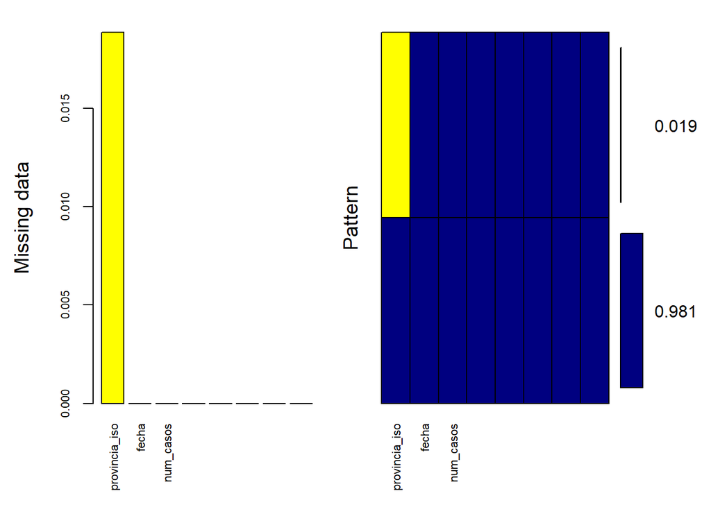

```
##
##  Variables sorted by number of missings:
##                      Variable      Count
##                 provincia_iso 0.01886792
##                         fecha 0.00000000
##                     num_casos 0.00000000
##          num_casos_prueba_pcr 0.00000000
##      num_casos_prueba_test_ac 0.00000000
##           num_casos_prueba_ag 0.00000000
##        num_casos_prueba_elisa 0.00000000
##  num_casos_prueba_desconocida 0.00000000
```

```r
aggr(CNE_tecnica, col=c('navyblue','yellow'),
     numbers=TRUE, sortVars=TRUE,
     labels=names(CNE_tecnica), cex.axis=.7,
     gap=3, ylab=c("Missing data","Pattern"))
```

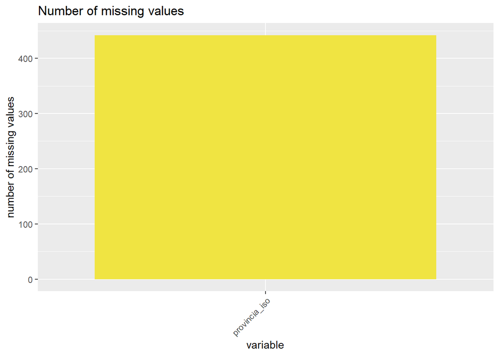

```r
CNE_tecnica %>%
    gather(key = "key", value = "val") %>%
    mutate(is.missing = is.na(val)) %>%
    group_by(key, is.missing) %>%
    summarise(num.missing = n()) %>%
    filter(is.missing==T) %>%
    select(-is.missing) %>%
    arrange(desc(num.missing)) %>%
    ggplot() +
    geom_bar(aes(x=key, y=num.missing), stat = 'identity',fill="#F0E442") +
    labs(x='variable', y="number of missing values",
         title='Number of missing values') +
    theme(axis.text.x = element_text(angle = 45, hjust = 1))
```

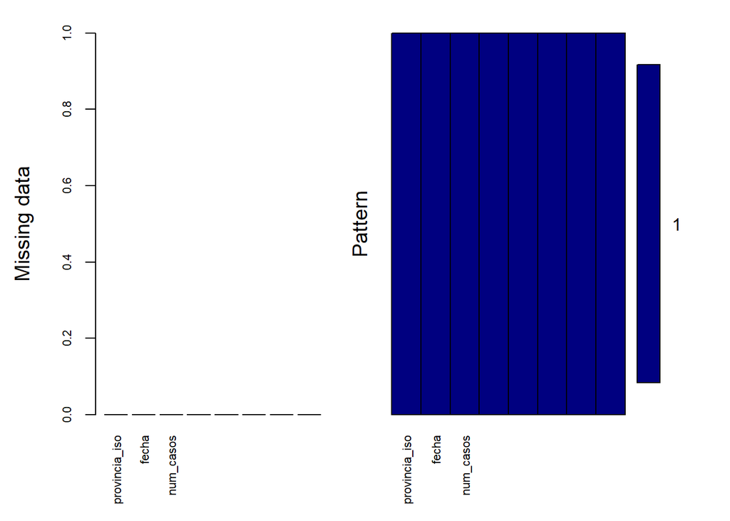

```
##
##  Variables sorted by number of missings:
##                      Variable Count
##                 provincia_iso     0
##                         fecha     0
##                     num_casos     0
##          num_casos_prueba_pcr     0
##      num_casos_prueba_test_ac     0
##           num_casos_prueba_ag     0
##        num_casos_prueba_elisa     0
##  num_casos_prueba_desconocida     0
```

```r
####################################
CNE_tecnica <- na.omit(CNE_tecnica)
####################################

aggr(CNE_tecnica, col=c('navyblue','yellow'),
     numbers=TRUE, sortVars=TRUE,
     labels=names(CNE_tecnica), cex.axis=.7,
     gap=3, ylab=c("Missing data","Pattern"))
```

```r
CNE_tecnica %>%
    gather(key = "key", value = "val") %>%
    mutate(is.missing = is.na(val)) %>%
    group_by(key, is.missing) %>%
    summarise(num.missing = n()) %>%
    filter(is.missing==T) %>%
    select(-is.missing) %>%
    arrange(desc(num.missing)) %>%
    ggplot() +
    geom_bar(aes(x=key, y=num.missing), stat = 'identity',fill="#F0E442") +
    labs(x='variable', y="number of missing values",
         title='Number of missing values') +
    theme(axis.text.x = element_text(angle = 45, hjust = 1))
```

```r
head(str(CNE_casos,vec.len=3))
```

```
## 'data.frame':    702780 obs. of  8 variables:
##  $ provincia_iso: chr  "A" "A" "A" ...
##  $ sexo         : chr  "H" "H" "H" ...
##  $ grupo_edad   : chr  "0-9" "10-19" "20-29" ...
##  $ fecha        : chr  "2020-01-01" "2020-01-01" "2020-01-01" ...
##  $ num_casos    : int  0 0 0 0 0 0 0 0 ...
##  $ num_hosp     : int  0 0 0 0 0 0 0 0 ...
##  $ num_uci      : int  0 0 0 0 0 0 0 0 ...
##  $ num_def      : int  0 0 0 0 0 0 0 0 ...
```

```r
summary(CNE_casos)
```

```
##  provincia_iso          sexo            grupo_edad           fecha
##  Length:702780      Length:702780      Length:702780      Length:702780
##  Class :character   Class :character   Class :character   Class :character
##  Mode  :character   Mode  :character   Mode  :character   Mode  :character
##
##
##
##    num_casos          num_hosp           num_uci            num_def
##  Min.   :  0.000   Min.   :  0.0000   Min.   : 0.00000   Min.   :  0.0000
##  1st Qu.:  0.000   1st Qu.:  0.0000   1st Qu.: 0.00000   1st Qu.:  0.0000
##  Median :  0.000   Median :  0.0000   Median : 0.00000   Median :  0.0000
##  Mean   :  4.562   Mean   :  0.4611   Mean   : 0.04117   Mean   :  0.1036
##  3rd Qu.:  2.000   3rd Qu.:  0.0000   3rd Qu.: 0.00000   3rd Qu.:  0.0000
##  Max.   :771.000   Max.   :269.0000   Max.   :35.00000   Max.   :100.0000
```

```r
table(CNE_casos$provincia_iso)
```

```
##
##     A    AB    AL    AV     B    BA    BI    BU     C    CA    CC    CE    CO
## 13260 13260 13260 13260 13260 13260 13260 13260 13260 13260 13260 13260 13260
##    CR    CS    CU    GC    GI    GR    GU     H    HU     J     L    LE    LO
## 13260 13260 13260 13260 13260 13260 13260 13260 13260 13260 13260 13260 13260
##    LU     M    MA    ML    MU    NC     O    OR     P    PM    PO     S    SA
## 13260 13260 13260 13260 13260 13260 13260 13260 13260 13260 13260 13260 13260
##    SE    SG    SO    SS     T    TE    TF    TO     V    VA    VI     Z    ZA
## 13260 13260 13260 13260 13260 13260 13260 13260 13260 13260 13260 13260 13260
```

We check missing values for CNE_casos. In this case also we omit the NA values.

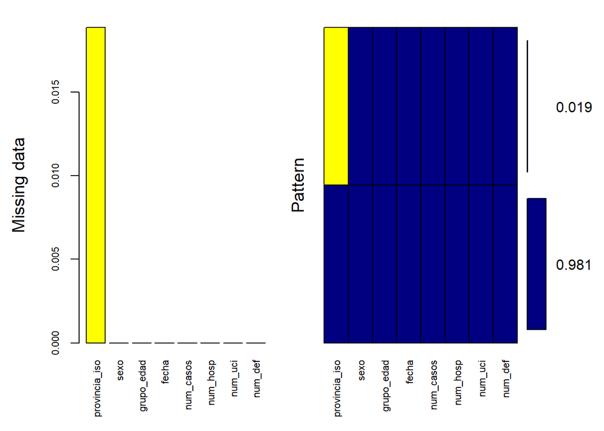

```
##
##  Variables sorted by number of missings:
##       Variable      Count
##  provincia_iso 0.01886792
##           sexo 0.00000000
##     grupo_edad 0.00000000
##          fecha 0.00000000
##      num_casos 0.00000000
##       num_hosp 0.00000000
##        num_uci 0.00000000
##        num_def 0.00000000
```

```r
aggr(CNE_casos, col=c('navyblue','yellow'),
     numbers=TRUE, sortVars=TRUE,
     labels=names(CNE_casos), cex.axis=.7,
     gap=3, ylab=c("Missing data","Pattern"))
```

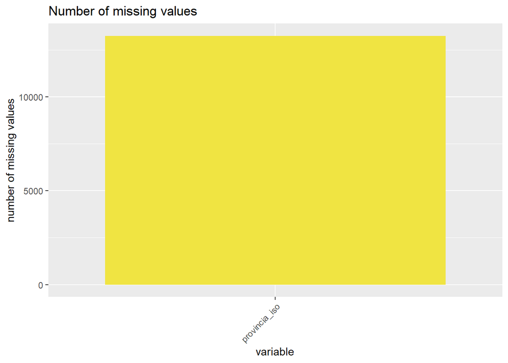

```r
CNE_casos %>%
    gather(key = "key", value = "val") %>%
    mutate(is.missing = is.na(val)) %>%
    group_by(key, is.missing) %>%
    summarise(num.missing = n()) %>%
    filter(is.missing==T) %>%
    select(-is.missing) %>%
    arrange(desc(num.missing)) %>%
    ggplot() +
    geom_bar(aes(x=key, y=num.missing), stat = 'identity',fill="#F0E442") +
    labs(x='variable', y="number of missing values",
         title='Number of missing values') +
    theme(axis.text.x = element_text(angle = 45, hjust = 1))
```

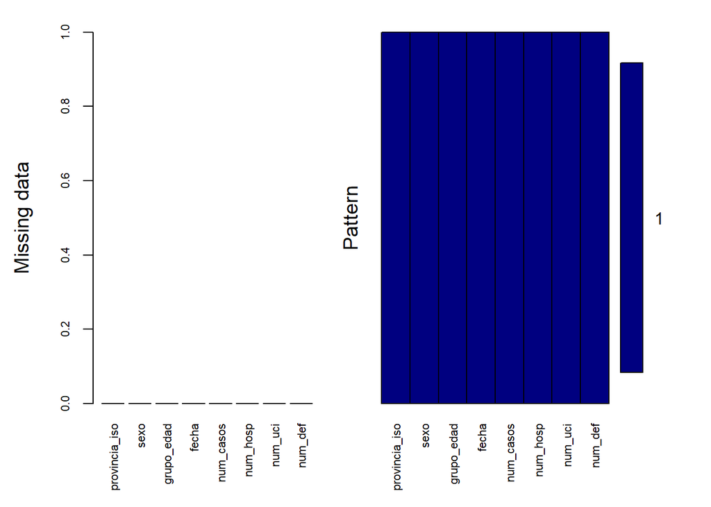

```
##
##  Variables sorted by number of missings:
##       Variable Count
##  provincia_iso     0
##           sexo     0
##     grupo_edad     0
##          fecha     0
##      num_casos     0
##       num_hosp     0
##        num_uci     0
##        num_def     0
```

```r
###############################
CNE_casos <- na.omit(CNE_casos)
###############################

aggr(CNE_casos, col=c('navyblue','yellow'),
     numbers=TRUE, sortVars=TRUE,
     labels=names(CNE_casos), cex.axis=.7,
     gap=3, ylab=c("Missing data","Pattern"))
```

```r
CNE_casos %>%
    gather(key = "key", value = "val") %>%
    mutate(is.missing = is.na(val)) %>%
    group_by(key, is.missing) %>%
    summarise(num.missing = n()) %>%
    filter(is.missing==T) %>%
    select(-is.missing) %>%
    arrange(desc(num.missing)) %>%
    ggplot() +
    geom_bar(aes(x=key, y=num.missing), stat = 'identity',fill="#F0E442") +
    labs(x='variable', y="number of missing values",
         title='Number of missing values') +
    theme(axis.text.x = element_text(angle = 45, hjust = 1))
```

### 2.1.11 CNE data transformation

We are going to **transform / eliminate**:

- A - “Fecha” column is transformed (in both datasets) from “character” to “date”.
- B - “Grupo_edad” and “Sexo” columns are eliminated from dataset “CNE_casos” due to they are not adding value (mobility does not include this variable).
- C - We change NC iso code to NA (Navarra) in both dataframes.

```r
# Transform / eliminate A
CNE_tecnica$fecha <- as.Date(CNE_tecnica$fecha ,format="%Y-%m-%d")
CNE_casos$fecha <- as.Date(CNE_casos$fecha ,format="%Y-%m-%d")

# Transform / eliminate B
CNE_casos<-within(CNE_casos, rm(grupo_edad, sexo))

# Iso code update for Navarra C
CNE_tecnica$provincia_iso[CNE_tecnica$provincia_iso=="NC"] <- "NA"
CNE_casos$provincia_iso[CNE_casos$provincia_iso=="NC"] <- "NA"

head(CNE_tecnica,5)
```

```
##   provincia_iso      fecha num_casos num_casos_prueba_pcr
## 1             A 2020-01-01         0                    0
## 2            AB 2020-01-01         0                    0
## 3            AL 2020-01-01         0                    0
## 4            AV 2020-01-01         0                    0
## 5             B 2020-01-01         0                    0
##   num_casos_prueba_test_ac num_casos_prueba_ag num_casos_prueba_elisa
## 1                        0                   0                      0
## 2                        0                   0                      0
## 3                        0                   0                      0
## 4                        0                   0                      0
## 5                        0                   0                      0
##   num_casos_prueba_desconocida
## 1                            0
## 2                            0
## 3                            0
## 4                            0
## 5                            0
```

```r
head(CNE_casos,5)
```

```
##   provincia_iso      fecha num_casos num_hosp num_uci num_def
## 1             A 2020-01-01         0        0       0       0
## 2             A 2020-01-01         0        0       0       0
## 3             A 2020-01-01         0        0       0       0
## 4             A 2020-01-01         0        0       0       0
## 5             A 2020-01-01         0        0       0       0
```

We check both dataframes offers the same total results.

```r
CNE_tecnica %>%
  group_by(provincia_iso) %>%
  summarise_at(vars(num_casos), sum)
```

```
## # A tibble: 52 x 2
##    provincia_iso num_casos
##    <chr>             <int>
##  1 A                143555
##  2 AB                26916
##  3 AL                47032
##  4 AV                11084
##  5 B                382992
##  6 BA                45886
##  7 BI                80588
##  8 BU                29808
##  9 C                 51272
## 10 CA                70428
## # ... with 42 more rows
```

```r
CNE_casos %>%
  group_by(provincia_iso) %>%
  summarise_at(vars(num_casos), sum)
```

```
## # A tibble: 52 x 2
##    provincia_iso num_casos
##    <chr>             <int>
##  1 A                143555
##  2 AB                26916
##  3 AL                47032
##  4 AV                11084
##  5 B                382992
##  6 BA                45886
##  7 BI                80588
##  8 BU                29808
##  9 C                 51272
## 10 CA                70428
## # ... with 42 more rows
```

## 2.2 Datasets combinations

We proceed to **combine** the different data sets into one.

### 2.2.1 CNE_tec_cas

- CNE_casos_g, a groupped dataframe due to the columns eliminated in previous step (grupo_edad, sexo)
- CNE_tec_cas -> CNE_tecnica + CNE_casos_g

Here we merge by columns “provincia_iso”,“fecha”.

```r
# CNE_casos_g
CNE_casos_g = CNE_casos %>%
  group_by(provincia_iso, fecha) %>%
  summarise_at(vars(num_casos, num_hosp, num_uci, num_def), sum)
head(CNE_casos_g,5)
```

```
## # A tibble: 5 x 6
## # Groups:   provincia_iso [1]
##   provincia_iso fecha      num_casos num_hosp num_uci num_def
##   <chr>         <date>         <int>    <int>   <int>   <int>
## 1 A             2020-01-01         0        1       0       0
## 2 A             2020-01-02         0        0       0       0
## 3 A             2020-01-03         0        0       0       0
## 4 A             2020-01-04         0        0       0       0
## 5 A             2020-01-05         0        1       0       0
```

```r
# New dataframe CNE_tec_cas
CNE_tec_cas<-merge(CNE_tecnica,
                   CNE_casos_g, by.x=c("provincia_iso","fecha"),
                   by.y=c("provincia_iso","fecha"))

# We check both dataframes offers the same total results
CNE_tecnica %>%
  group_by(provincia_iso) %>%
  summarise_at(vars(num_casos), sum)
```

```
## # A tibble: 52 x 2
##    provincia_iso num_casos
##    <chr>             <int>
##  1 A                143555
##  2 AB                26916
##  3 AL                47032
##  4 AV                11084
##  5 B                382992
##  6 BA                45886
##  7 BI                80588
##  8 BU                29808
##  9 C                 51272
## 10 CA                70428
## # ... with 42 more rows
```

```r
CNE_casos_g %>%
  group_by(provincia_iso) %>%
  summarise_at(vars(num_casos), sum)
```

```
## # A tibble: 52 x 2
##    provincia_iso num_casos
##    <chr>             <int>
##  1 A                143555
##  2 AB                26916
##  3 AL                47032
##  4 AV                11084
##  5 B                382992
##  6 BA                45886
##  7 BI                80588
##  8 BU                29808
##  9 C                 51272
## 10 CA                70428
## # ... with 42 more rows
```

```r
head(CNE_tec_cas,5)
```

```
##   provincia_iso      fecha num_casos.x num_casos_prueba_pcr
## 1             A 2020-01-01           0                    0
## 2             A 2020-01-02           0                    0
## 3             A 2020-01-03           0                    0
## 4             A 2020-01-04           0                    0
## 5             A 2020-01-05           0                    0
##   num_casos_prueba_test_ac num_casos_prueba_ag num_casos_prueba_elisa
## 1                        0                   0                      0
## 2                        0                   0                      0
## 3                        0                   0                      0
## 4                        0                   0                      0
## 5                        0                   0                      0
##   num_casos_prueba_desconocida num_casos.y num_hosp num_uci num_def
## 1                            0           0        1       0       0
## 2                            0           0        0       0       0
## 3                            0           0        0       0       0
## 4                            0           0        0       0       0
## 5                            0           0        1       0       0
```

```r
table(CNE_tec_cas$provincia_iso)
```

```
##
##   A  AB  AL  AV   B  BA  BI  BU   C  CA  CC  CE  CO  CR  CS  CU  GC  GI  GR  GU
## 442 442 442 442 442 442 442 442 442 442 442 442 442 442 442 442 442 442 442 442
##   H  HU   J   L  LE  LO  LU   M  MA  ML  MU  NA   O  OR   P  PM  PO   S  SA  SE
## 442 442 442 442 442 442 442 442 442 442 442 442 442 442 442 442 442 442 442 442
##  SG  SO  SS   T  TE  TF  TO   V  VA  VI   Z  ZA
## 442 442 442 442 442 442 442 442 442 442 442 442
```

### 2.2.2 GOG_CNE

- GOG_CNE -> CNE_tec_cas + Google

```r
# New dataframe GOG_CNE
GOG_CNE<-merge(CNE_tec_cas,
               Google,
               by.x=c("provincia_iso","fecha"),
               by.y=c("iso_code","Date"))
head(GOG_CNE,5)
```

```
##   provincia_iso      fecha num_casos.x num_casos_prueba_pcr
## 1             A 2020-02-15           1                    1
## 2             A 2020-02-16           1                    1
## 3             A 2020-02-17           1                    1
## 4             A 2020-02-18           1                    1
## 5             A 2020-02-19           1                    1
##   num_casos_prueba_test_ac num_casos_prueba_ag num_casos_prueba_elisa
## 1                        0                   0                      0
## 2                        0                   0                      0
## 3                        0                   0                      0
## 4                        0                   0                      0
## 5                        0                   0                      0
##   num_casos_prueba_desconocida num_casos.y num_hosp num_uci num_def
## 1                            0           0        1       0       0
## 2                            0           0        0       0       0
```

[output cut: 39 more lines]

```r
table(GOG_CNE$provincia_iso)
```

```
##
##   A  AB  AL  AV   B  BA  BI  BU   C  CA  CC  CE  CO  CR  CS  CU  GC  GI  GR  GU
## 385 385 385 385 385 385 385 385 385 385 385 385 385 385 385 385 385 385 385 385
##   H  HU   J   L  LE  LO  LU   M  MA  ML  MU  NA   O  OR   P  PM  PO   S  SA  SE
## 385 385 385 385 385 385 385 385 385 385 385 385 385 385 385 385 385 385 385 385
##  SG  SO  SS   T  TE  TF  TO   V  VA  VI   Z  ZA
## 385 385 385 385 385 385 385 385 385 385 385 385
```

### 2.2.3 Total

- Total -> GOG_CNE + EM3

```r
# New dataframe Total
Total<-merge(GOG_CNE,
             EM3,
             by.x=c("sub_region_2","fecha"),
             by.y=c("Zonas.de.movilidad","Periodo"))
head(Total,5)
```

```
##   sub_region_2      fecha provincia_iso num_casos.x num_casos_prueba_pcr
## 1     Albacete 2020-03-16            AB         137                  132
## 2     Albacete 2020-03-17            AB         128                  123
## 3     Albacete 2020-03-18            AB         114                  107
## 4     Albacete 2020-03-19            AB         149                  133
## 5     Albacete 2020-03-20            AB         131                  121
##   num_casos_prueba_test_ac num_casos_prueba_ag num_casos_prueba_elisa
## 1                        5                   0                      0
## 2                        5                   0                      0
## 3                        7                   0                      0
## 4                       16                   0                      0
## 5                       10                   0                      0
##   num_casos_prueba_desconocida num_casos.y num_hosp num_uci num_def
## 1                            0          65       43       3       7
## 2                            0          29       40       4       2
```

[output cut: 39 more lines]

```r
head(str(Total,vec.len=1))
```

```
## 'data.frame':    15080 obs. of  20 variables:
##  $ sub_region_2                                      : chr  "Albacete" ...
##  $ fecha                                             : Date, format: "2020-03-16" ...
##  $ provincia_iso                                     : chr  "AB" ...
##  $ num_casos.x                                       : int  137 128 ...
##  $ num_casos_prueba_pcr                              : int  132 123 ...
##  $ num_casos_prueba_test_ac                          : int  5 5 ...
##  $ num_casos_prueba_ag                               : int  0 0 ...
##  $ num_casos_prueba_elisa                            : int  0 0 ...
##  $ num_casos_prueba_desconocida                      : int  0 0 ...
##  $ num_casos.y                                       : int  65 29 ...
##  $ num_hosp                                          : int  43 40 ...
##  $ num_uci                                           : int  3 4 ...
##  $ num_def                                           : int  7 2 ...
##  $ retail_and_recreation_percent_change_from_baseline: num  -81 -84 ...
##  $ grocery_and_pharmacy_percent_change_from_baseline : num  -32 -41 ...
##  $ parks_percent_change_from_baseline                : num  -73 -74 ...
##  $ transit_stations_percent_change_from_baseline     : num  -66 -72 ...
##  $ workplaces_percent_change_from_baseline           : num  -51 -56 ...
##  $ residential_percent_change_from_baseline          : num  22 23 ...
##  $ Total                                             : num  9.9 ...
```

```r
summary(Total)
```

```
##  sub_region_2           fecha            provincia_iso       num_casos.x
##  Length:15080       Min.   :2020-03-16   Length:15080       Min.   :   0
##  Class :character   1st Qu.:2020-05-27   Class :character   1st Qu.:   5
##  Mode  :character   Median :2020-08-07   Mode  :character   Median :  39
##                     Mean   :2020-08-07                      Mean   : 126
##                     3rd Qu.:2020-10-19                      3rd Qu.: 120
##                     Max.   :2020-12-30                      Max.   :6565
##  num_casos_prueba_pcr num_casos_prueba_test_ac num_casos_prueba_ag
##  Min.   :   0.0       Min.   : 0.0000          Min.   :   0.00
##  1st Qu.:   5.0       1st Qu.: 0.0000          1st Qu.:   0.00
##  Median :  35.0       Median : 0.0000          Median :   0.00
##  Mean   : 110.2       Mean   : 0.2832          Mean   :  15.19
##  3rd Qu.: 105.0       3rd Qu.: 0.0000          3rd Qu.:   4.00
##  Max.   :6546.0       Max.   :32.0000          Max.   :1465.00
##  num_casos_prueba_elisa num_casos_prueba_desconocida  num_casos.y
##  Min.   : 0.0000        Min.   : 0.0000              Min.   :   0
##  1st Qu.: 0.0000        1st Qu.: 0.0000              1st Qu.:   6
##  Median : 0.0000        Median : 0.0000              Median :  37
##  Mean   : 0.1989        Mean   : 0.1317              Mean   : 127
##  3rd Qu.: 0.0000        3rd Qu.: 0.0000              3rd Qu.: 117
##  Max.   :71.0000        Max.   :65.0000              Max.   :7724
##     num_hosp          num_uci           num_def
##  Min.   :   0.00   Min.   :  0.000   Min.   :  0.000
##  1st Qu.:   1.00   1st Qu.:  0.000   1st Qu.:  0.000
##  Median :   4.00   Median :  0.000   Median :  1.000
##  Mean   :  14.86   Mean   :  1.281   Mean   :  3.437
##  3rd Qu.:  12.00   3rd Qu.:  1.000   3rd Qu.:  3.000
##  Max.   :1930.00   Max.   :135.000   Max.   :334.000
##  retail_and_recreation_percent_change_from_baseline
##  Min.   :-97.00
##  1st Qu.:-57.00
##  Median :-30.00
##  Mean   :-37.29
##  3rd Qu.:-17.00
##  Max.   : 71.00
##  grocery_and_pharmacy_percent_change_from_baseline
##  Min.   :-96.00
##  1st Qu.:-24.00
##  Median : -6.00
##  Mean   :-11.75
```

[output cut: 15 more lines]

```
##  Max.   :  74.00
##  workplaces_percent_change_from_baseline
##  Min.   :-92.00
##  1st Qu.:-43.00
##  Median :-26.00
##  Mean   :-29.08
##  3rd Qu.:-13.00
##  Max.   : 55.00
##  residential_percent_change_from_baseline     Total
##  Min.   :-10.00                           Min.   : 1.95
##  1st Qu.:  4.00                           1st Qu.:11.36
##  Median :  7.00                           Median :14.39
##  Mean   : 10.14                           Mean   :14.20
##  3rd Qu.: 14.00                           3rd Qu.:17.11
##  Max.   : 48.00                           Max.   :29.00
```

```r
table(Total$sub_region_2)
```

```
##
##               Albacete       Alicante/Alacant                Almería
##                    290                    290                    290
##            Araba/Álava               Asturias                  Ávila
##                    290                    290                    290
##                Badajoz         Balears, Illes              Barcelona
##                    290                    290                    290
##                Bizkaia                 Burgos                Cáceres
##                    290                    290                    290
##                  Cádiz              Cantabria     Castellón/Castelló
##                    290                    290                    290
##                  Ceuta            Ciudad Real                Córdoba
##                    290                    290                    290
##              Coruña, A                 Cuenca               Gipuzkoa
##                    290                    290                    290
##                 Girona                Granada            Guadalajara
##                    290                    290                    290
##                 Huelva                 Huesca                   Jaén
##                    290                    290                    290
##                   León                 Lleida                   Lugo
##                    290                    290                    290
##                 Madrid                 Málaga                Melilla
##                    290                    290                    290
##                 Murcia                Navarra                Ourense
##                    290                    290                    290
##               Palencia            Palmas, Las             Pontevedra
##                    290                    290                    290
##              Rioja, La              Salamanca Santa Cruz de Tenerife
##                    290                    290                    290
##                Segovia                Sevilla                  Soria
##                    290                    290                    290
##              Tarragona                 Teruel                 Toledo
##                    290                    290                    290
##      Valencia/València             Valladolid                 Zamora
##                    290                    290                    290
##               Zaragoza
##                    290
```

```r
table(Total$provincia_iso)
```

```
##
##   A  AB  AL  AV   B  BA  BI  BU   C  CA  CC  CE  CO  CR  CS  CU  GC  GI  GR  GU
## 290 290 290 290 290 290 290 290 290 290 290 290 290 290 290 290 290 290 290 290
##   H  HU   J   L  LE  LO  LU   M  MA  ML  MU  NA   O  OR   P  PM  PO   S  SA  SE
## 290 290 290 290 290 290 290 290 290 290 290 290 290 290 290 290 290 290 290 290
##  SG  SO  SS   T  TE  TF  TO   V  VA  VI   Z  ZA
## 290 290 290 290 290 290 290 290 290 290 290 290
```

We check the missing values. We should have zero missing values

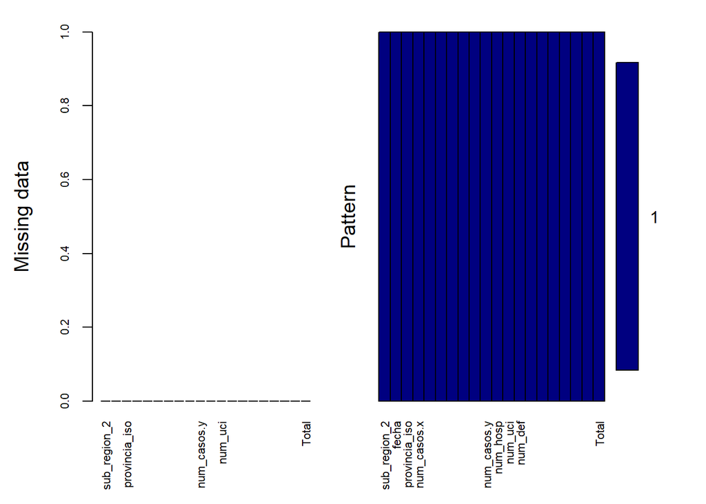

```
##
##  Variables sorted by number of missings:
##                                            Variable Count
##                                        sub_region_2     0
##                                               fecha     0
##                                       provincia_iso     0
##                                         num_casos.x     0
##                                num_casos_prueba_pcr     0
##                            num_casos_prueba_test_ac     0
##                                 num_casos_prueba_ag     0
##                              num_casos_prueba_elisa     0
##                        num_casos_prueba_desconocida     0
##                                         num_casos.y     0
##                                            num_hosp     0
##                                             num_uci     0
##                                             num_def     0
##  retail_and_recreation_percent_change_from_baseline     0
##   grocery_and_pharmacy_percent_change_from_baseline     0
##                  parks_percent_change_from_baseline     0
##       transit_stations_percent_change_from_baseline     0
##             workplaces_percent_change_from_baseline     0
##            residential_percent_change_from_baseline     0
##                                               Total     0
```

```r
aggr(Total, col=c('navyblue','yellow'),
     numbers=TRUE, sortVars=TRUE,
     labels=names(Total), cex.axis=.7,
     gap=3, ylab=c("Missing data","Pattern"))
```

```r
Total %>%
    gather(key = "key", value = "val") %>%
    mutate(is.missing = is.na(val)) %>%
    group_by(key, is.missing) %>%
    summarise(num.missing = n()) %>%
    filter(is.missing==T) %>%
    select(-is.missing) %>%
    arrange(desc(num.missing)) %>%
    ggplot() +
    geom_bar(aes(x=key, y=num.missing), stat = 'identity',fill="#F0E442") +
    labs(x='variable', y="number of missing values",
         title='Number of missing values') +
    theme(axis.text.x = element_text(angle = 45, hjust = 1))
```

```r
# Review results
# Discrepancies due to different time-frames when merge CNE dataframes (see previous checks)
Total %>%
  group_by(provincia_iso) %>%
  summarise_at(vars(num_casos.x,num_casos.y), sum)
```

```
## # A tibble: 52 x 3
##    provincia_iso num_casos.x num_casos.y
##    <chr>               <int>       <int>
##  1 A                   56493       55068
##  2 AB                  16459       16626
##  3 AL                  21488       21372
##  4 AV                   6525        6681
##  5 B                  257034      261208
##  6 BA                  23165       22612
##  7 BI                  56867       57728
##  8 BU                  22742       22978
##  9 C                   25641       25604
## 10 CA                  31593       31225
## # ... with 42 more rows
```

```r
# CSV file generation
head(Total,5)
```

```
##   sub_region_2      fecha provincia_iso num_casos.x num_casos_prueba_pcr
## 1     Albacete 2020-03-16            AB         137                  132
## 2     Albacete 2020-03-17            AB         128                  123
## 3     Albacete 2020-03-18            AB         114                  107
## 4     Albacete 2020-03-19            AB         149                  133
## 5     Albacete 2020-03-20            AB         131                  121
##   num_casos_prueba_test_ac num_casos_prueba_ag num_casos_prueba_elisa
## 1                        5                   0                      0
## 2                        5                   0                      0
## 3                        7                   0                      0
## 4                       16                   0                      0
## 5                       10                   0                      0
##   num_casos_prueba_desconocida num_casos.y num_hosp num_uci num_def
## 1                            0          65       43       3       7
## 2                            0          29       40       4       2
```

[output cut: 39 more lines]

```r
str(Total)
```

```
## 'data.frame':    15080 obs. of  20 variables:
##  $ sub_region_2                                      : chr  "Albacete" "Albacete" "Albacete" "Albacete" ...
##  $ fecha                                             : Date, format: "2020-03-16" "2020-03-17" ...
##  $ provincia_iso                                     : chr  "AB" "AB" "AB" "AB" ...
##  $ num_casos.x                                       : int  137 128 114 149 131 129 125 112 107 78 ...
##  $ num_casos_prueba_pcr                              : int  132 123 107 133 121 120 112 103 91 64 ...
##  $ num_casos_prueba_test_ac                          : int  5 5 7 16 10 9 13 9 16 14 ...
##  $ num_casos_prueba_ag                               : int  0 0 0 0 0 0 0 0 0 0 ...
##  $ num_casos_prueba_elisa                            : int  0 0 0 0 0 0 0 0 0 0 ...
##  $ num_casos_prueba_desconocida                      : int  0 0 0 0 0 0 0 0 0 0 ...
##  $ num_casos.y                                       : int  65 29 26 22 85 24 60 194 53 22 ...
##  $ num_hosp                                          : int  43 40 24 40 63 60 61 108 76 66 ...
##  $ num_uci                                           : int  3 4 7 5 4 2 8 2 7 9 ...
##  $ num_def                                           : int  7 2 7 7 6 10 13 16 14 16 ...
##  $ retail_and_recreation_percent_change_from_baseline: num  -81 -84 -83 -93 -87 -92 -94 -85 -87 -87 ...
##  $ grocery_and_pharmacy_percent_change_from_baseline : num  -32 -41 -32 -92 -34 -60 -80 -46 -55 -55 ...
##  $ parks_percent_change_from_baseline                : num  -73 -74 -70 -80 -74 -85 -88 -77 -81 -76 ...
##  $ transit_stations_percent_change_from_baseline     : num  -66 -72 -70 -86 -76 -80 -89 -76 -79 -78 ...
##  $ workplaces_percent_change_from_baseline           : num  -51 -56 -58 -85 -68 -64 -66 -61 -64 -65 ...
##  $ residential_percent_change_from_baseline          : num  22 23 23 35 32 27 23 26 28 28 ...
##  $ Total                                             : num  9.9 9.71 9.51 9.13 8.75 ...
```

```r
summary(Total)
```

```
##  sub_region_2           fecha            provincia_iso       num_casos.x
##  Length:15080       Min.   :2020-03-16   Length:15080       Min.   :   0
##  Class :character   1st Qu.:2020-05-27   Class :character   1st Qu.:   5
##  Mode  :character   Median :2020-08-07   Mode  :character   Median :  39
##                     Mean   :2020-08-07                      Mean   : 126
##                     3rd Qu.:2020-10-19                      3rd Qu.: 120
##                     Max.   :2020-12-30                      Max.   :6565
##  num_casos_prueba_pcr num_casos_prueba_test_ac num_casos_prueba_ag
##  Min.   :   0.0       Min.   : 0.0000          Min.   :   0.00
##  1st Qu.:   5.0       1st Qu.: 0.0000          1st Qu.:   0.00
##  Median :  35.0       Median : 0.0000          Median :   0.00
##  Mean   : 110.2       Mean   : 0.2832          Mean   :  15.19
##  3rd Qu.: 105.0       3rd Qu.: 0.0000          3rd Qu.:   4.00
##  Max.   :6546.0       Max.   :32.0000          Max.   :1465.00
##  num_casos_prueba_elisa num_casos_prueba_desconocida  num_casos.y
##  Min.   : 0.0000        Min.   : 0.0000              Min.   :   0
##  1st Qu.: 0.0000        1st Qu.: 0.0000              1st Qu.:   6
##  Median : 0.0000        Median : 0.0000              Median :  37
##  Mean   : 0.1989        Mean   : 0.1317              Mean   : 127
##  3rd Qu.: 0.0000        3rd Qu.: 0.0000              3rd Qu.: 117
##  Max.   :71.0000        Max.   :65.0000              Max.   :7724
##     num_hosp          num_uci           num_def
##  Min.   :   0.00   Min.   :  0.000   Min.   :  0.000
##  1st Qu.:   1.00   1st Qu.:  0.000   1st Qu.:  0.000
##  Median :   4.00   Median :  0.000   Median :  1.000
##  Mean   :  14.86   Mean   :  1.281   Mean   :  3.437
##  3rd Qu.:  12.00   3rd Qu.:  1.000   3rd Qu.:  3.000
##  Max.   :1930.00   Max.   :135.000   Max.   :334.000
##  retail_and_recreation_percent_change_from_baseline
##  Min.   :-97.00
##  1st Qu.:-57.00
##  Median :-30.00
##  Mean   :-37.29
##  3rd Qu.:-17.00
##  Max.   : 71.00
##  grocery_and_pharmacy_percent_change_from_baseline
##  Min.   :-96.00
##  1st Qu.:-24.00
##  Median : -6.00
##  Mean   :-11.75
```

[output cut: 15 more lines]

```
##  Max.   :  74.00
##  workplaces_percent_change_from_baseline
##  Min.   :-92.00
##  1st Qu.:-43.00
##  Median :-26.00
##  Mean   :-29.08
##  3rd Qu.:-13.00
##  Max.   : 55.00
##  residential_percent_change_from_baseline     Total
##  Min.   :-10.00                           Min.   : 1.95
##  1st Qu.:  4.00                           1st Qu.:11.36
##  Median :  7.00                           Median :14.39
##  Mean   : 10.14                           Mean   :14.20
##  3rd Qu.: 14.00                           3rd Qu.:17.11
##  Max.   : 48.00                           Max.   :29.00
```

```r
table(Total$provincia_iso)
```

```
##
##   A  AB  AL  AV   B  BA  BI  BU   C  CA  CC  CE  CO  CR  CS  CU  GC  GI  GR  GU
## 290 290 290 290 290 290 290 290 290 290 290 290 290 290 290 290 290 290 290 290
##   H  HU   J   L  LE  LO  LU   M  MA  ML  MU  NA   O  OR   P  PM  PO   S  SA  SE
## 290 290 290 290 290 290 290 290 290 290 290 290 290 290 290 290 290 290 290 290
##  SG  SO  SS   T  TE  TF  TO   V  VA  VI   Z  ZA
## 290 290 290 290 290 290 290 290 290 290 290 290
```

```r
write.csv2(Total,"D:\\UOC Master Data Science\\_ M2.882 - TFM - Área 5\\UOC - Guia - PECS\\Pec3\\Total.csv", row.names = FALSE)
```

## 2.3 Visual analysis

### 2.3.1 Dataframe plots

We have generated some plots from the **dataframe** object generated.

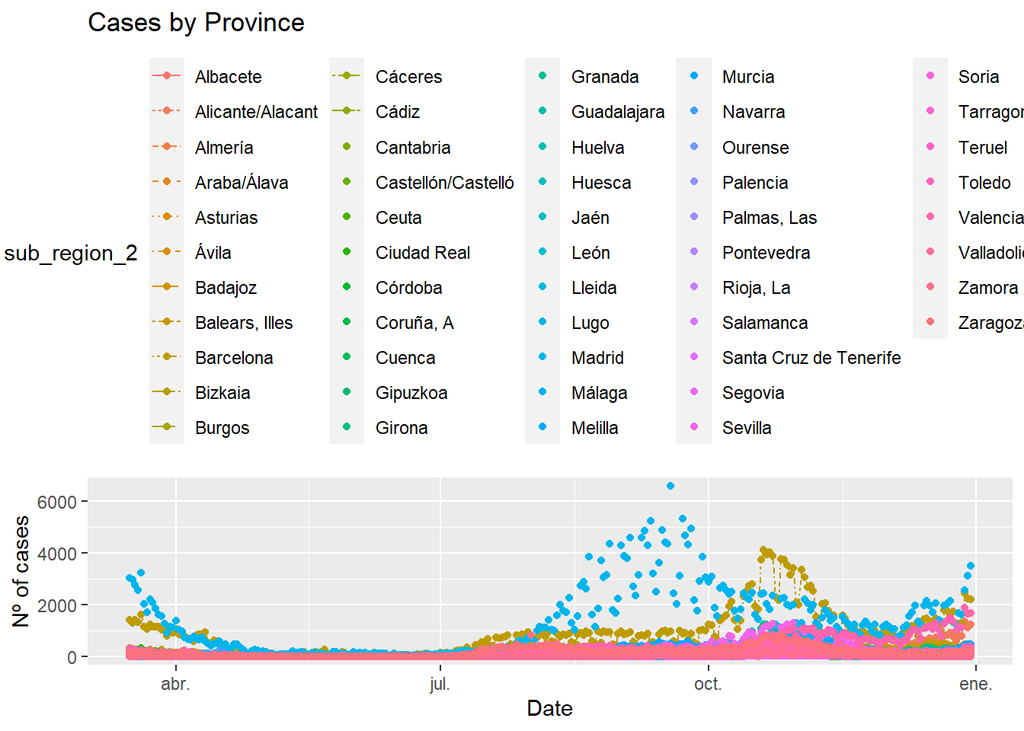

```r
# Line plots
# All num_casos.x
ggplot(Total, aes(x=fecha, y=num_casos.x, group=sub_region_2)) +
  geom_line(aes(linetype=sub_region_2, color=sub_region_2))+
  geom_point(aes(color=sub_region_2))+
  theme(legend.position="top") +
  labs(title="Cases by Province",
        x ="Date", y = "Nº of cases")
```

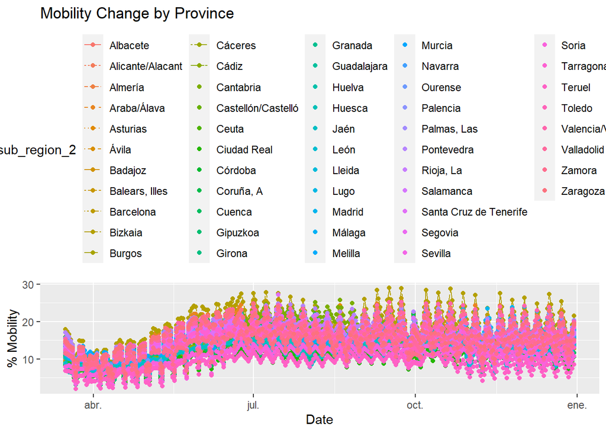

```r
# All Total (mobility)
ggplot(Total, aes(x=fecha, y=Total, group=sub_region_2)) +
  geom_line(aes(linetype=sub_region_2, color=sub_region_2))+
  geom_point(aes(color=sub_region_2))+
  theme(legend.position="top") +
  labs(title="Mobility Change by Province",
        x ="Date", y = "% Mobility")
```

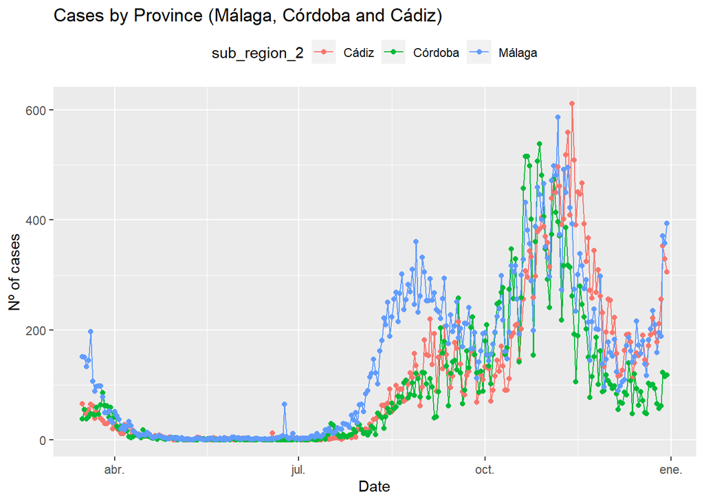

```r
# Mal, Cor and Cad - num_casos.x
Total %>%
  filter(sub_region_2 == "Málaga" | sub_region_2 == "Cádiz" |
         sub_region_2 == "Córdoba") %>%
  ggplot(aes(x=fecha, y=num_casos.x))+
    geom_line(aes(color=sub_region_2))+
    geom_point(aes(color=sub_region_2))+
    theme(legend.position="top") +
    labs(title="Cases by Province (Málaga, Córdoba and Cádiz)",
        x ="Date", y = "Nº of cases")
```

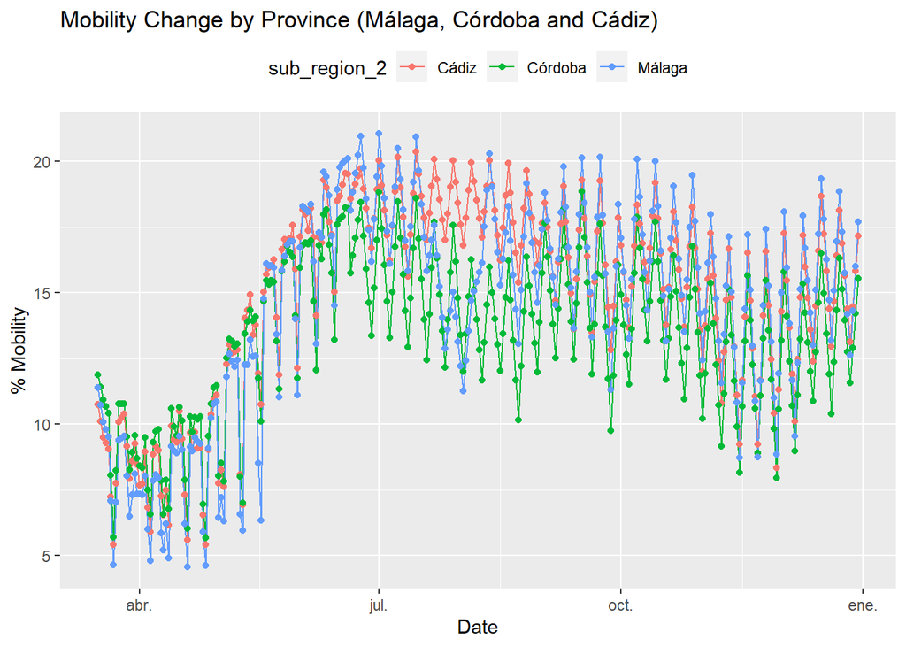

```r
# Mal, Cor and Cad - Total (mobility)
Total %>%
  filter(sub_region_2 == "Málaga" | sub_region_2 == "Cádiz" |
         sub_region_2 == "Córdoba") %>%
  ggplot(aes(x=fecha, y=Total))+
    geom_line(aes(color=sub_region_2))+
    geom_point(aes(color=sub_region_2))+
    theme(legend.position="top") +
  labs(title="Mobility Change by Province (Málaga, Córdoba and Cádiz)",
        x ="Date", y = "% Mobility")
```